# Function definitions

# $\Lambda_b^0 \to p K^- \gamma$

Model definition: [`lb2pkg-lhcb-2765817.json`](https://github.com/RUB-EP1/amplitude-serialization/blob/main/models/lb2pkg-lhcb-2765817.json).

This page demonstrates deserialization and evaluation of an amplitude model for the decay $\Lambda_b^0 \to p K^- \gamma$. The resonant structure is studied using proton-proton collision data recorded at centre-of-mass energies of $7$, $8$, and $13$ TeV collected with the LHCb detector, [INSPIRE-HEP 2765817](https://inspirehep.net/literature/2765817).

**Activate environment**

```julia
using Pkg: Pkg
Pkg.activate(@__DIR__)
Pkg.instantiate()

using ThreeBodyDecaysIO
using ThreeBodyDecaysIO.ThreeBodyDecays
using ThreeBodyDecaysIO.HadronicLineshapes
using ThreeBodyDecaysIO.Parameters
using ThreeBodyDecaysIO.DataFrames
using ThreeBodyDecaysIO.JSON
using Measurements
using Statistics
using QuadGK
using Plots
using LaTeXStrings

theme(:wong2, frame=:box, grid=false, minorticks=true,
    guidefontvalign=:top, guidefonthalign=:right,
    foreground_color_legend=nothing,
    xlim=(:auto, :auto), ylim=(:auto, :auto),
    lab="")
```

## Deserialization of Objects to a Workspace

Model components are deserialized from a JSON file into computational objects within a workspace for further manipulation. First, functions representing lineshapes and form-factors are built. Following this, distributions are processed and added to the workspace.

```julia
input = open(joinpath(@__DIR__, "..", "..", "models", "lb2pkg-lhcb-2765817.json")) do io
    JSON.parse(io)
end

workspace = Dict{String,Any}()

@unpack functions = input
for fn in functions
    @unpack name, type = fn
    instance_type = eval(Symbol(type))
    workspace[name] = dict2instance(instance_type, fn)
end

@unpack distributions = input
for dist in distributions
    @unpack name, type = dist
    instance_type = eval(Symbol(type))
    workspace[name] = dict2instance(instance_type, dist; workspace)
end
```

## Validation

The integrity of the model is checked by validating the value of distributions at a few phase space points. The table lists the validation checks and their status. The marks “🟢”, “🟡”, and “🔴” indicate an accuracy of $<10^{-10}$, $<10^{-2}$, or $\ge10^{-2}$, respectively, for the difference between the reference and computed values.

**A loop over validation points**

```julia
df = let
    @unpack misc, parameter_points = input
    @unpack amplitude_model_checksums = misc

    map(amplitude_model_checksums) do check_point_info
        @unpack point, value, distribution = check_point_info
        #
        # pull distribution
        dist = workspace[distribution]

        # pull correct parameter point
        parameter_points_dict = array2dict(parameter_points; key="name")
        # find the point in the list of points
        parameter_point = parameter_points_dict[point]
        # compute, compare
        _parameters = array2dict(parameter_point["parameters"];
            key="name", apply=v -> v["value"])
        #
        computed_value = dist(_parameters)
        #
        tonumber(X::Number) = X
        tonumber(X::String) = string2complex(X)
        reference_value = tonumber(value)
        status = label_diff(reference_value - computed_value; levels=[1e-2, 1e-10])
        #
        (; Distribution=distribution, Reference=value, Computed_value=computed_value,
            Point=point, Status=status)
    end |> DataFrame
end
```

17×5 DataFrame

[output not shown]

## Visualization

The model describing the decay is fetched from the workspace

```julia
model_dist = [v for (k, v) in workspace if v isa HadronicUnpolarizedIntensity] |> first;
model = model_dist.model
```

```
ThreeBodyDecay{74, DecayChain{X, ThreeBodySystem{@NamedTuple{m1::Float64, m2::Float64, m3::Float64, m0::Float64}, @NamedTuple{two_h1::Int64, two_h2::Int64, two_h3::Int64, two_h0::Int64}}} where X, ComplexF64, String}
  chains: StaticArraysCore.SVector{74, DecayChain{X, ThreeBodySystem{@NamedTuple{m1::Float64, m2::Float64, m3::Float64, m0::Float64}, @NamedTuple{two_h1::Int64, two_h2::Int64, two_h3::Int64, two_h0::Int64}}} where X}
  couplings: StaticArraysCore.SVector{74, ComplexF64}
  names: StaticArraysCore.SVector{74, String}
```

### Dalitz plot

**Dalitz plot plotting**

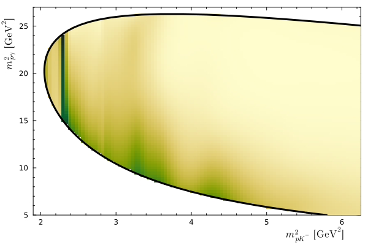

```julia
let
    ms = masses(model)
    #
    σ3v = range(1.9, 2.5^2, 100)
    σ2v = range(5, 27, 80)
    #
    _model = model
    f(σs) = Kibble(σs, ms^2) > 0 ? NaN : unpolarized_intensity(model, σs)

    values = [f(Invariants(ms; σ3, σ2)) for σ2 in σ2v, σ3 in σ3v]
    heatmap(σ3v, σ2v, values, colorbar=false, c=:speed)
    plot!(border32(masses(model)),
        l=(3, :black),
        xlim=(σ3v[1], σ3v[end]), ylim=(σ2v[1], σ2v[end]),
        xlab=L"m_{pK^-}^2\,\, [\textrm{GeV}^2]",
        ylab=L"m_{p\gamma}^2\,\, [\textrm{GeV}^2]")
end
```

The projection of the model onto a mass variable is shown by black line. Contributions from individual resonances are shown by the colored lines.

**Computation of projections**

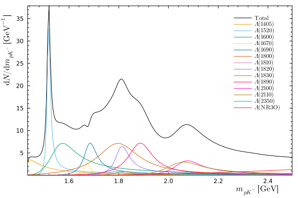

```julia
let k = 3
    i, j = ij_from_k(k)
    model = model_dist.model
    #
    mlims = (sqrt(lims(3, masses(model))[1]), 2.5)
    mv = range(mlims..., 200) |> shift_by_half
    #
    plot()
    plot!(mv, lab=L"\textrm{Total}") do m
        I = Base.Fix1(unpolarized_intensity, model)
        m * quadgk(projection_integrand(I, masses(model), m^2; k), 0, 1)[1] / 1e3
    end
    chain_names = Set(model.names) |> collect |> sort
    for name in chain_names
        _model = model[model.names.==name]
        lab = replace(name, "L" => "\\varLambda(\\textrm{") * "})"
        plot!(mv, lab=latexstring(lab)) do m
            I = Base.Fix1(unpolarized_intensity, _model)
            m * quadgk(projection_integrand(I, masses(_model), m^2; k), 0, 1)[1] / 1e3
        end
    end
    plot!(;
        xlab=L"m_{pK^-}\,\, [\textrm{GeV}]",
        ylab=L"\textrm{d} N /\textrm{d} m_{pK^-}\,\, [\textrm{GeV}^{-1}]")
end
```